# R Notebook-Pepperwood Hobo Data Analysis

```r
knitr::opts_chunk$set(echo = TRUE)
library(ggplot2)
library(dplyr)
```

R Markdown - Individual files

```r
pws <-read.csv("data/PPW_HOBO_2016_Master.csv")
str(pws)
```

```
'data.frame':   865886 obs. of  5 variables:
 $ X        : int  34115 34116 34117 34118 34119 34120 34121 34122 34123 34124 ...
 $ Date.Time: Factor w/ 52877 levels "2016-01-01 00:00:00",..: 1 4 7 10 13 16 19 22 25 28 ...
 $ Temp     : num  1.99 1.97 1.86 1.86 1.1 ...
 $ RH       : num  49.7 49.4 49.6 47.7 50.3 ...
 $ Plot     : int  1301 1301 1301 1301 1301 1301 1301 1301 1301 1301 ...
```

```r
summary(pws)
```

```
       X                         Date.Time           Temp              RH              Plot
 Min.   :  34115   2016-07-13 15:00:00:    48   Min.   :-94.79   Min.   :  1.00   Min.   :1301
 1st Qu.: 810541   2016-07-13 15:30:00:    48   1st Qu.:  9.78   1st Qu.: 59.46   1st Qu.:1313
 Median :1566310   2016-07-13 16:00:00:    48   Median : 12.70   Median : 82.64   Median :1325
 Mean   :1588889   2016-07-13 16:30:00:    48   Mean   : 14.24   Mean   : 76.37   Mean   :1325
 3rd Qu.:2390877   2016-07-13 17:00:00:    48   3rd Qu.: 17.96   3rd Qu.: 97.20   3rd Qu.:1338
 Max.   :3152032   2016-07-13 17:30:00:    48   Max.   : 62.40   Max.   :100.00   Max.   :1350
                   (Other)            :865598   NA's   :180      NA's   :180
```

Check the imported columns

```r
str(pws)
```

```
'data.frame':   865886 obs. of  5 variables:
 $ X        : int  34115 34116 34117 34118 34119 34120 34121 34122 34123 34124 ...
 $ Date.Time: Factor w/ 52877 levels "2016-01-01 00:00:00",..: 1 4 7 10 13 16 19 22 25 28 ...
 $ Temp     : num  1.99 1.97 1.86 1.86 1.1 ...
 $ RH       : num  49.7 49.4 49.6 47.7 50.3 ...
 $ Plot     : int  1301 1301 1301 1301 1301 1301 1301 1301 1301 1301 ...
```

```r
head(pws)
```

|  | X | Date.Time | Temp | RH | Plot |
| --- | --- | --- | --- | --- | --- |
| 1 | 34115 | 2016-01-01 00:00:00 | 1.994 | 49.741 | 1301 |
| 2 | 34116 | 2016-01-01 00:30:00 | 1.967 | 49.380 | 1301 |
| 3 | 34117 | 2016-01-01 01:00:00 | 1.859 | 49.574 | 1301 |
| 4 | 34118 | 2016-01-01 01:30:00 | 1.859 | 47.725 | 1301 |
| 5 | 34119 | 2016-01-01 02:00:00 | 1.099 | 50.268 | 1301 |
| 6 | 34120 | 2016-01-01 02:30:00 | 1.317 | 50.358 | 1301 |

```r
pws$tsfmt<- as.POSIXct(pws$Date.Time,format="%Y-%m-%d %H:%M:%S")
head(pws)
```

|  | X | Date.Time | Temp | RH | Plot | tsfmt |
| --- | --- | --- | --- | --- | --- | --- |
| 1 | 34115 | 2016-01-01 00:00:00 | 1.994 | 49.741 | 1301 | 2016-01-01 00:00:00 |
| 2 | 34116 | 2016-01-01 00:30:00 | 1.967 | 49.380 | 1301 | 2016-01-01 00:30:00 |
| 3 | 34117 | 2016-01-01 01:00:00 | 1.859 | 49.574 | 1301 | 2016-01-01 01:00:00 |
| 4 | 34118 | 2016-01-01 01:30:00 | 1.859 | 47.725 | 1301 | 2016-01-01 01:30:00 |
| 5 | 34119 | 2016-01-01 02:00:00 | 1.099 | 50.268 | 1301 | 2016-01-01 02:00:00 |
| 6 | 34120 | 2016-01-01 02:30:00 | 1.317 | 50.358 | 1301 | 2016-01-01 02:30:00 |

Lets try to do the summary by site, day for the 2016 data for RH and Temperature

```r
head(pws %>%mutate(HR= format(tsfmt,"%H"),DATE=format(tsfmt,"%Y-%m-%d")) %>% group_by(Plot,DATE,HR) %>% summarise(minHrlyTemp = min(Temp),maxHrlyTemp = max(Temp),meanHrlyTemp = mean(Temp),minHrlyRH = min(RH),maxHrlyRH = max(RH),meanHrlyRH = mean(RH)) %>% as.data.frame())
```

|  | Plot | DATE | HR | minHrlyTemp | maxHrlyTemp | meanHrlyTemp | minHrlyRH | maxHrlyRH | meanHrlyRH |
| --- | --- | --- | --- | --- | --- | --- | --- | --- | --- |
| 1 | 1301 | 2016-01-01 | 00 | 1.967 | 1.994 | 1.9805 | 49.380 | 49.741 | 49.5605 |
| 2 | 1301 | 2016-01-01 | 01 | 1.859 | 1.859 | 1.8590 | 47.725 | 49.574 | 48.6495 |
| 3 | 1301 | 2016-01-01 | 02 | 1.099 | 1.317 | 1.2080 | 50.268 | 50.358 | 50.3130 |
| 4 | 1301 | 2016-01-01 | 03 | 1.480 | 1.724 | 1.6020 | 46.896 | 48.394 | 47.6450 |
| 5 | 1301 | 2016-01-01 | 04 | 0.439 | 0.880 | 0.6595 | 47.594 | 50.618 | 49.1060 |
| 6 | 1301 | 2016-01-01 | 05 | 0.384 | 1.289 | 0.8365 | 47.858 | 49.517 | 48.6875 |

Lets write to CSV

```r
pws %>%mutate(HR= format(tsfmt,"%H"),DATE=format(tsfmt,"%Y-%m-%d")) %>% group_by(Plot,DATE,HR) %>% summarise(minHrlyTemp = min(Temp),maxHrlyTemp = max(Temp),meanHrlyTemp = mean(Temp),minHrlyRH = min(RH),maxHrlyRH = max(RH),meanHrlyRH = mean(RH)) %>% as.data.frame() %>% write.csv("data/Hobo-2016-Summary-Hourly.csv")
```

Now, lets create the daily file. We can follow the same, but now summarize by DATE

```r
pws %>%mutate(HR= format(tsfmt,"%H"),DATE=format(tsfmt,"%Y-%m-%d")) %>% group_by(Plot,DATE) %>% summarise(minHrlyTemp = min(Temp),maxHrlyTemp = max(Temp),maxHrlyTemp = max(Temp),minHrlyRH = min(RH),maxHrlyRH = max(RH),meanHrlyRH = mean(RH)) %>% as.data.frame() %>% write.csv("data/Hobo-2016-Summary-Daily.csv")
```

Lets validate our files, criteria a) Number of collection points

```r
ht2016<- read.csv('./data/Hobo-2016-Summary-Hourly.csv')
str(ht2016)
```

```
'data.frame':   425941 obs. of  10 variables:
 $ X           : int  1 2 3 4 5 6 7 8 9 10 ...
 $ Plot        : int  1301 1301 1301 1301 1301 1301 1301 1301 1301 1301 ...
 $ DATE        : Factor w/ 366 levels "2016-01-01","2016-01-02",..: 1 1 1 1 1 1 1 1 1 1 ...
 $ HR          : int  0 1 2 3 4 5 6 7 8 9 ...
 $ minHrlyTemp : num  1.967 1.859 1.099 1.48 0.439 ...
 $ maxHrlyTemp : num  1.99 1.86 1.32 1.72 0.88 ...
 $ meanHrlyTemp: num  1.98 1.859 1.208 1.602 0.659 ...
 $ minHrlyRH   : num  49.4 47.7 50.3 46.9 47.6 ...
 $ maxHrlyRH   : num  49.7 49.6 50.4 48.4 50.6 ...
 $ meanHrlyRH  : num  49.6 48.6 50.3 47.6 49.1 ...
```

```r
head(ht2016)
```

|  | X | Plot | DATE | HR | minHrlyTemp | maxHrlyTemp | meanHrlyTemp | minHrlyRH | maxHrlyRH | meanHrlyRH |
| --- | --- | --- | --- | --- | --- | --- | --- | --- | --- | --- |
| 1 | 1 | 1301 | 2016-01-01 | 0 | 1.967 | 1.994 | 1.9805 | 49.380 | 49.741 | 49.5605 |
| 2 | 2 | 1301 | 2016-01-01 | 1 | 1.859 | 1.859 | 1.8590 | 47.725 | 49.574 | 48.6495 |
| 3 | 3 | 1301 | 2016-01-01 | 2 | 1.099 | 1.317 | 1.2080 | 50.268 | 50.358 | 50.3130 |
| 4 | 4 | 1301 | 2016-01-01 | 3 | 1.480 | 1.724 | 1.6020 | 46.896 | 48.394 | 47.6450 |
| 5 | 5 | 1301 | 2016-01-01 | 4 | 0.439 | 0.880 | 0.6595 | 47.594 | 50.618 | 49.1060 |
| 6 | 6 | 1301 | 2016-01-01 | 5 | 0.384 | 1.289 | 0.8365 | 47.858 | 49.517 | 48.6875 |

Housekeeping , convert date from factor to a datetype, and add Month

```r
ht2016$dt <- as.Date(ht2016$DATE, "%Y-%m-%d")
str(ht2016)
```

```
'data.frame':   425941 obs. of  11 variables:
 $ X           : int  1 2 3 4 5 6 7 8 9 10 ...
 $ Plot        : int  1301 1301 1301 1301 1301 1301 1301 1301 1301 1301 ...
 $ DATE        : Factor w/ 366 levels "2016-01-01","2016-01-02",..: 1 1 1 1 1 1 1 1 1 1 ...
 $ HR          : int  0 1 2 3 4 5 6 7 8 9 ...
 $ minHrlyTemp : num  1.967 1.859 1.099 1.48 0.439 ...
 $ maxHrlyTemp : num  1.99 1.86 1.32 1.72 0.88 ...
 $ meanHrlyTemp: num  1.98 1.859 1.208 1.602 0.659 ...
 $ minHrlyRH   : num  49.4 47.7 50.3 46.9 47.6 ...
 $ maxHrlyRH   : num  49.7 49.6 50.4 48.4 50.6 ...
 $ meanHrlyRH  : num  49.6 48.6 50.3 47.6 49.1 ...
 $ dt          : Date, format: "2016-01-01" "2016-01-01" "2016-01-01" "2016-01-01" ...
```

```r
# Check for the Sanity of data
summary(ht2016)
```

```
       X               Plot              DATE              HR        minHrlyTemp       maxHrlyTemp
 Min.   :     1   Min.   :1301   2016-01-01:  1176   Min.   : 0.0   Min.   :-94.792   Min.   :-89.421
 1st Qu.:106486   1st Qu.:1313   2016-01-02:  1176   1st Qu.: 6.0   1st Qu.:  9.608   1st Qu.:  9.977
 Median :212971   Median :1325   2016-01-03:  1176   Median :12.0   Median : 12.485   Median : 12.920
 Mean   :212971   Mean   :1325   2016-01-04:  1176   Mean   :11.5   Mean   : 13.941   Mean   : 14.544
 3rd Qu.:319456   3rd Qu.:1338   2016-01-05:  1176   3rd Qu.:18.0   3rd Qu.: 17.510   3rd Qu.: 18.414
 Max.   :425941   Max.   :1350   2016-01-06:  1176   Max.   :23.0   Max.   : 62.032   Max.   : 62.395
                                 (Other)   :418885                  NA's   :90        NA's   :90
  meanHrlyTemp       minHrlyRH        maxHrlyRH        meanHrlyRH           dt
 Min.   :-92.106   Min.   :  1.00   Min.   :  1.00   Min.   :  1.00   Min.   :2016-01-01
 1st Qu.:  9.793   1st Qu.: 57.76   1st Qu.: 61.33   1st Qu.: 59.59   1st Qu.:2016-03-31
 Median : 12.703   Median : 81.28   Median : 84.06   Median : 82.64   Median :2016-07-02
 Mean   : 14.243   Mean   : 75.36   Mean   : 77.45   Mean   : 76.40   Mean   :2016-07-01
 3rd Qu.: 17.962   3rd Qu.: 96.69   3rd Qu.: 97.69   3rd Qu.: 97.14   3rd Qu.:2016-10-01
 Max.   : 62.123   Max.   :100.00   Max.   :100.00   Max.   :100.00   Max.   :2016-12-31
 NA's   :90        NA's   :90       NA's   :90       NA's   :90
```

There are some corrupt values in Temperature, research the issue

```r
ht2016$dt <- as.Date(ht2016$DATE, "%Y-%m-%d")
str(ht2016)
```

```
'data.frame':   425941 obs. of  11 variables:
 $ X           : int  1 2 3 4 5 6 7 8 9 10 ...
 $ Plot        : int  1301 1301 1301 1301 1301 1301 1301 1301 1301 1301 ...
 $ DATE        : Factor w/ 366 levels "2016-01-01","2016-01-02",..: 1 1 1 1 1 1 1 1 1 1 ...
 $ HR          : int  0 1 2 3 4 5 6 7 8 9 ...
 $ minHrlyTemp : num  1.967 1.859 1.099 1.48 0.439 ...
 $ maxHrlyTemp : num  1.99 1.86 1.32 1.72 0.88 ...
 $ meanHrlyTemp: num  1.98 1.859 1.208 1.602 0.659 ...
 $ minHrlyRH   : num  49.4 47.7 50.3 46.9 47.6 ...
 $ maxHrlyRH   : num  49.7 49.6 50.4 48.4 50.6 ...
 $ meanHrlyRH  : num  49.6 48.6 50.3 47.6 49.1 ...
 $ dt          : Date, format: "2016-01-01" "2016-01-01" "2016-01-01" "2016-01-01" ...
```

```r
# Check for the Sanity of data
summary(ht2016)
```

```
       X               Plot              DATE              HR        minHrlyTemp       maxHrlyTemp
 Min.   :     1   Min.   :1301   2016-01-01:  1176   Min.   : 0.0   Min.   :-94.792   Min.   :-89.421
 1st Qu.:106486   1st Qu.:1313   2016-01-02:  1176   1st Qu.: 6.0   1st Qu.:  9.608   1st Qu.:  9.977
 Median :212971   Median :1325   2016-01-03:  1176   Median :12.0   Median : 12.485   Median : 12.920
 Mean   :212971   Mean   :1325   2016-01-04:  1176   Mean   :11.5   Mean   : 13.941   Mean   : 14.544
 3rd Qu.:319456   3rd Qu.:1338   2016-01-05:  1176   3rd Qu.:18.0   3rd Qu.: 17.510   3rd Qu.: 18.414
 Max.   :425941   Max.   :1350   2016-01-06:  1176   Max.   :23.0   Max.   : 62.032   Max.   : 62.395
                                 (Other)   :418885                  NA's   :90        NA's   :90
  meanHrlyTemp       minHrlyRH        maxHrlyRH        meanHrlyRH           dt
 Min.   :-92.106   Min.   :  1.00   Min.   :  1.00   Min.   :  1.00   Min.   :2016-01-01
 1st Qu.:  9.793   1st Qu.: 57.76   1st Qu.: 61.33   1st Qu.: 59.59   1st Qu.:2016-03-31
 Median : 12.703   Median : 81.28   Median : 84.06   Median : 82.64   Median :2016-07-02
 Mean   : 14.243   Mean   : 75.36   Mean   : 77.45   Mean   : 76.40   Mean   :2016-07-01
 3rd Qu.: 17.962   3rd Qu.: 96.69   3rd Qu.: 97.69   3rd Qu.: 97.14   3rd Qu.:2016-10-01
 Max.   : 62.123   Max.   :100.00   Max.   :100.00   Max.   :100.00   Max.   :2016-12-31
 NA's   :90        NA's   :90       NA's   :90       NA's   :90
```

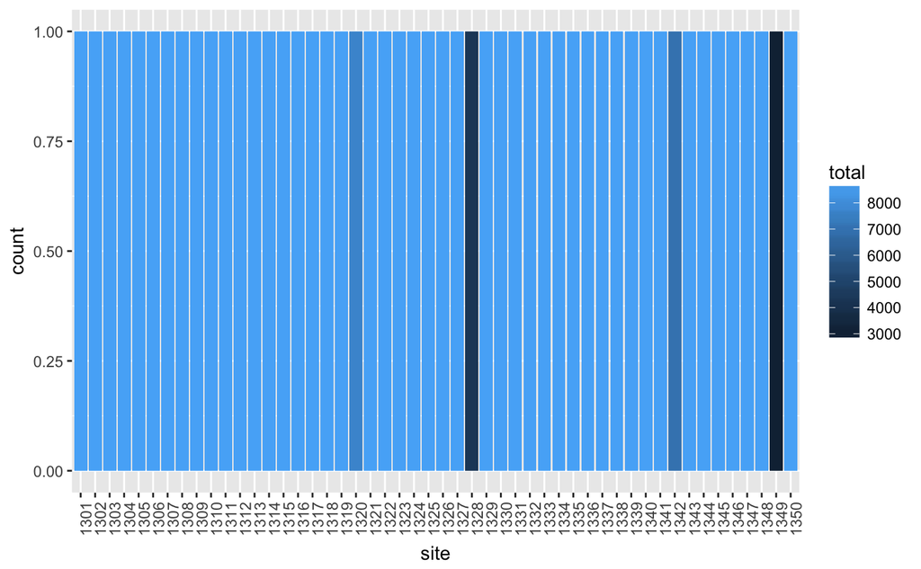

```r
ht2016 %>% mutate(site = as.factor(Plot)) %>%
group_by(site) %>%
summarise(total = n()) %>% ggplot(aes(x=site,fill=total)) +
geom_bar() +
theme(axis.text.x = element_text(angle = 90, hjust = 1))
```

Different way of looking at same, we expect for each plot 24 points for a day, so that makes it 24*365 (approx 8760 points for a site) . We get 2 by site every hour.

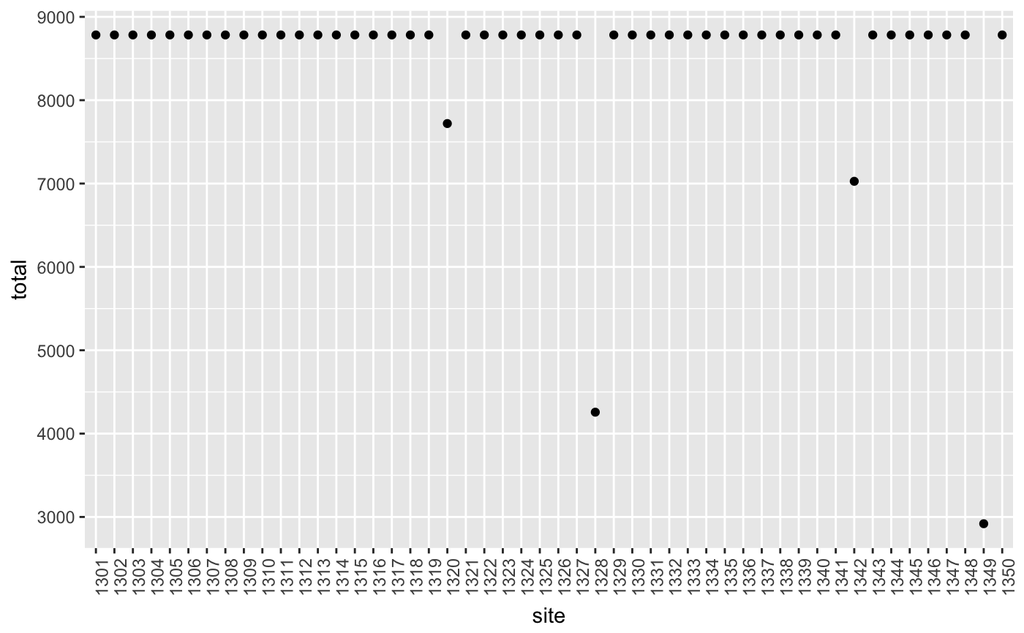

```r
ht2016 %>%  mutate(site = as.factor(Plot)) %>%
group_by(site) %>%
summarise(total = n()) %>% ggplot(aes(x=site,y=total)) +
geom_point() +
theme(axis.text.x = element_text(angle = 90, hjust = 1))
```

Issue with 1328 and 1349 collection, so have less than half the required points, so we can drop it from analysis.

Now, lets look at the unusually high temperatures

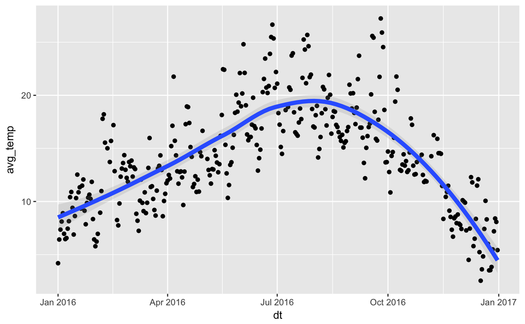

```r
ht2016 %>% group_by(dt)  %>% summarise(avg_temp=mean(meanHrlyTemp)) %>% ggplot(aes(dt,avg_temp)) +
geom_point() + geom_smooth(alpha=.2, size=2)
```

So, mostly looks good, lets look at it closer.

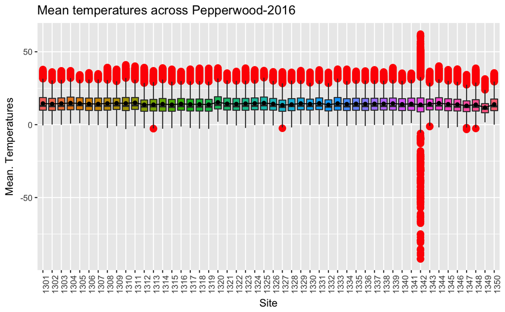

```r
p1 <- ggplot(ht2016, aes(factor(Plot), meanHrlyTemp))
p1 <- p1 + geom_boxplot(aes(fill = factor(Plot)),outlier.colour = "red", outlier.size = 3) + theme(axis.text.x = element_text(angle = 90, hjust = 1),legend.position="none") + ggtitle("Mean temperatures across Pepperwood-2016") + xlab("Site") +
ylab("Mean. Temperatures")+ stat_summary(fun.y=mean, geom="line", aes(group=1))  +
stat_summary(fun.y=mean, geom="point")
p1
```

Issue with 1342 , putting it all out of whack.

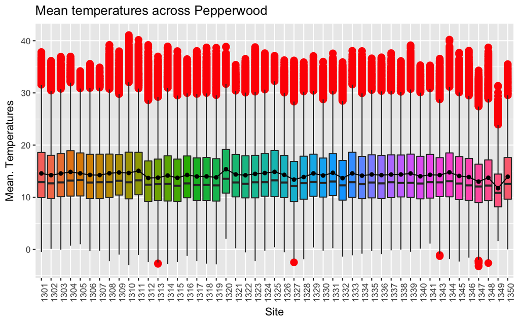

```r
p1 <- ggplot(ht2016 %>% filter(!(Plot %in% c(1342))), aes(factor(Plot), meanHrlyTemp))
p1 <- p1 + geom_boxplot(aes(fill = factor(Plot)),outlier.colour = "red", outlier.size = 3) + theme(axis.text.x = element_text(angle = 90, hjust = 1),legend.position="none") + ggtitle("Mean temperatures across Pepperwood") + xlab("Site") +
ylab("Mean. Temperatures")+ stat_summary(fun.y=mean, geom="line", aes(group=1))  +
stat_summary(fun.y=mean, geom="point")
p1
```

```r
str(ht2016)
```

```
'data.frame':   425941 obs. of  11 variables:
 $ X           : int  1 2 3 4 5 6 7 8 9 10 ...
 $ Plot        : int  1301 1301 1301 1301 1301 1301 1301 1301 1301 1301 ...
 $ DATE        : Factor w/ 366 levels "2016-01-01","2016-01-02",..: 1 1 1 1 1 1 1 1 1 1 ...
 $ HR          : int  0 1 2 3 4 5 6 7 8 9 ...
 $ minHrlyTemp : num  1.967 1.859 1.099 1.48 0.439 ...
 $ maxHrlyTemp : num  1.99 1.86 1.32 1.72 0.88 ...
 $ meanHrlyTemp: num  1.98 1.859 1.208 1.602 0.659 ...
 $ minHrlyRH   : num  49.4 47.7 50.3 46.9 47.6 ...
 $ maxHrlyRH   : num  49.7 49.6 50.4 48.4 50.6 ...
 $ meanHrlyRH  : num  49.6 48.6 50.3 47.6 49.1 ...
 $ dt          : Date, format: "2016-01-01" "2016-01-01" "2016-01-01" "2016-01-01" ...
```

```r
head(ht2016 %>% mutate(MONTH= format(dt,"%m"),DAY= format(dt,"%d")) %>% as.data.frame())
```

|  | X | Plot | DATE | HR | minHrlyTemp | maxHrlyTemp | meanHrlyTemp | minHrlyRH | maxHrlyRH | meanHrlyRH | dt | MONTH | DAY |
| --- | --- | --- | --- | --- | --- | --- | --- | --- | --- | --- | --- | --- | --- |
| 1 | 1 | 1301 | 2016-01-01 | 0 | 1.967 | 1.994 | 1.9805 | 49.380 | 49.741 | 49.5605 | 2016-01-01 | 01 | 01 |
| 2 | 2 | 1301 | 2016-01-01 | 1 | 1.859 | 1.859 | 1.8590 | 47.725 | 49.574 | 48.6495 | 2016-01-01 | 01 | 01 |
| 3 | 3 | 1301 | 2016-01-01 | 2 | 1.099 | 1.317 | 1.2080 | 50.268 | 50.358 | 50.3130 | 2016-01-01 | 01 | 01 |
| 4 | 4 | 1301 | 2016-01-01 | 3 | 1.480 | 1.724 | 1.6020 | 46.896 | 48.394 | 47.6450 | 2016-01-01 | 01 | 01 |
| 5 | 5 | 1301 | 2016-01-01 | 4 | 0.439 | 0.880 | 0.6595 | 47.594 | 50.618 | 49.1060 | 2016-01-01 | 01 | 01 |
| 6 | 6 | 1301 | 2016-01-01 | 5 | 0.384 | 1.289 | 0.8365 | 47.858 | 49.517 | 48.6875 | 2016-01-01 | 01 | 01 |

```r
str(ht2016)
```

```
'data.frame':   425941 obs. of  11 variables:
 $ X           : int  1 2 3 4 5 6 7 8 9 10 ...
 $ Plot        : int  1301 1301 1301 1301 1301 1301 1301 1301 1301 1301 ...
 $ DATE        : Factor w/ 366 levels "2016-01-01","2016-01-02",..: 1 1 1 1 1 1 1 1 1 1 ...
 $ HR          : int  0 1 2 3 4 5 6 7 8 9 ...
 $ minHrlyTemp : num  1.967 1.859 1.099 1.48 0.439 ...
 $ maxHrlyTemp : num  1.99 1.86 1.32 1.72 0.88 ...
 $ meanHrlyTemp: num  1.98 1.859 1.208 1.602 0.659 ...
 $ minHrlyRH   : num  49.4 47.7 50.3 46.9 47.6 ...
 $ maxHrlyRH   : num  49.7 49.6 50.4 48.4 50.6 ...
 $ meanHrlyRH  : num  49.6 48.6 50.3 47.6 49.1 ...
 $ dt          : Date, format: "2016-01-01" "2016-01-01" "2016-01-01" "2016-01-01" ...
```

```r
head(ht2016 %>% mutate(MONTH= format(dt,"%m"),DAY= format(dt,"%d")) %>% as.data.frame())
```

|  | X | Plot | DATE | HR | minHrlyTemp | maxHrlyTemp | meanHrlyTemp | minHrlyRH | maxHrlyRH | meanHrlyRH | dt | MONTH | DAY |
| --- | --- | --- | --- | --- | --- | --- | --- | --- | --- | --- | --- | --- | --- |
| 1 | 1 | 1301 | 2016-01-01 | 0 | 1.967 | 1.994 | 1.9805 | 49.380 | 49.741 | 49.5605 | 2016-01-01 | 01 | 01 |
| 2 | 2 | 1301 | 2016-01-01 | 1 | 1.859 | 1.859 | 1.8590 | 47.725 | 49.574 | 48.6495 | 2016-01-01 | 01 | 01 |
| 3 | 3 | 1301 | 2016-01-01 | 2 | 1.099 | 1.317 | 1.2080 | 50.268 | 50.358 | 50.3130 | 2016-01-01 | 01 | 01 |
| 4 | 4 | 1301 | 2016-01-01 | 3 | 1.480 | 1.724 | 1.6020 | 46.896 | 48.394 | 47.6450 | 2016-01-01 | 01 | 01 |
| 5 | 5 | 1301 | 2016-01-01 | 4 | 0.439 | 0.880 | 0.6595 | 47.594 | 50.618 | 49.1060 | 2016-01-01 | 01 | 01 |
| 6 | 6 | 1301 | 2016-01-01 | 5 | 0.384 | 1.289 | 0.8365 | 47.858 | 49.517 | 48.6875 | 2016-01-01 | 01 | 01 |

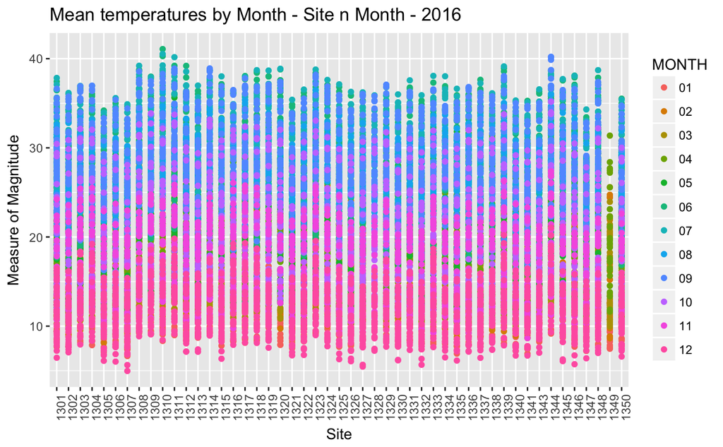

```r
ht2016$site<- as.factor(ht2016$Plot)
ht2016 %>% filter(!(Plot %in% c(1342))) %>% mutate(MONTH= format(dt,"%m"),DAY= format(dt,"%d")) %>% filter(MONTH %in% c('01','02','03','04','05','06','07','08','09','10','11','12')) %>% group_by(site,MONTH,DAY) %>%
    summarise(
              min_temp = min(meanHrlyTemp),
              max_temp = max(meanHrlyTemp),
              mean_temp = max(meanHrlyTemp),
              diu_fluct = max_temp - min_temp ,
              total = n()) %>% ggplot(aes(site,mean_temp, color=MONTH)) + geom_point() +  theme(axis.text.x = element_text(angle = 90, hjust = 1)) + ggtitle("Mean temperatures by Month - Site n Month - 2016") + xlab("Site") + ylab("Measure of Magnitude")
```

Looks ok, lets look at daily Diurnal fluctuation

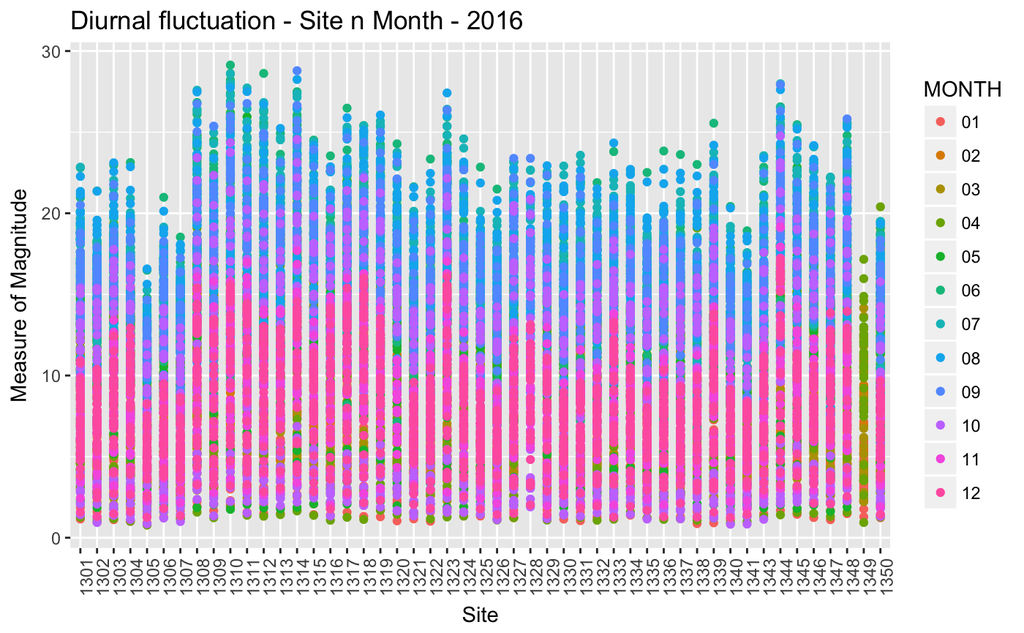

```r
ht2016$site<- as.factor(ht2016$Plot)
ht2016 %>% filter(!(Plot %in% c(1342))) %>% mutate(MONTH= format(dt,"%m"),DAY= format(dt,"%d")) %>% filter(MONTH %in% c('01','02','03','04','05','06','07','08','09','10','11','12')) %>% group_by(site,MONTH,DAY) %>%
    summarise(
              min_temp = min(meanHrlyTemp),
              max_temp = max(meanHrlyTemp),
              diu_fluct = max_temp - min_temp ,
              total = n()) %>% ggplot(aes(site,diu_fluct, color=MONTH)) + geom_point() +  theme(axis.text.x = element_text(angle = 90, hjust = 1)) + ggtitle("Diurnal fluctuation - Site n Month - 2016") + xlab("Site") + ylab("Measure of Magnitude")
```